# Online Retail Dataset Case Study - (Short Form)

Thomas Dluzniewski

2025-08-26

## Foreword

This is a shortened form of the extremely technical and lengthy report for a case study report done on Online Retail transaction data found on Kaggle. To find the aforementioned long form of this report, stay in the “Documents” (where this report is located) and select the other report besides this one.

## Introduction to the Case Study

This is a data analytics case study utilizing an online retail transaction data set found on Kaggle (a link will be provided below). In this analysis, we will be working with online retail transaction data from a UK-based retail company which contains a variety of different data relevant to figuring out optimal stocking strategies and being able to pinpoint which products sell well (and which ones do not) throughout a calendar year, which is the goal of this case study.

We will be working on this analysis using Microsoft Excel, the R programming language, and SQL to extract useful inventory insights, create effective and digestible visualizations, and deliver a clear solution for a retail business. Overall, this case study will be used for inventory managers and executives in the company concerned with stocking throughout a typical year.

The important questions we will ask that will be answered later will be:

- What products need to be prioritized in stocking?
- What times of year does stocking need to be prioritized?
- What countries need to be prioritized in stocking?
- What products are bought by recurring customers?

Deliverables for this case study:

- A cleaned data set that clearly shows proper cleaning techniques
- A well defined markdown made in an R Markdown File
- Data visualizations from R which demonstrate key findings
- SQL queries that indicate valuable findings (averages, popular products, etc)
- Three Tableau dashboards that give readers a clearer view of the data

*Note: Throughout this report, we will be using the Ask, Prepare, Process, Analyze, Share, Act phases for a optimized response*

## What is This Dataset?

This is an online retail transaction data set that sources its information from an anonymous UK-based online retailer. In the data set, there is information ranging from the types of products sold, individual orders, invoice numbers, dates, and a lot of other relevant information for a variety of different business problems such as inventory optimization, predictive analysis, detecting fraud, and customer segmentation.

In this report, we will be prioritizing inventory optimization but we will make other findings that fit in terms of detecting fraud and customer segmentation.

As stated above, we will cross paths with some of the other issues mentioned above (such as fraud) and will incorporate it into our report.

## Preparing the Dataset

```
## 'data.frame':    541909 obs. of  9 variables:
##  $ index      : int  0 1 2 3 4 5 6 7 8 9 ...
##  $ InvoiceNo  : chr  "536365" "536365" "536365" "536365" ...
##  $ StockCode  : chr  "85123A" "71053" "84406B" "84029G" ...
##  $ Description: chr  "WHITE HANGING HEART T-LIGHT HOLDER" "WHITE METAL LANTERN" "CREAM CUPID HEARTS COAT HANGER" "KNITTED UNION FLAG HOT WATER BOTTLE" ...
##  $ Quantity   : int  6 6 8 6 6 2 6 6 6 32 ...
##  $ InvoiceDate: chr  "12/1/10 8:26" "12/1/10 8:26" "12/1/10 8:26" "12/1/10 8:26" ...
##  $ UnitPrice  : num  2.55 3.39 2.75 3.39 3.39 7.65 4.25 1.85 1.85 1.69 ...
##  $ CustomerID : int  17850 17850 17850 17850 17850 17850 17850 17850 17850 13047 ...
##  $ Country    : chr  "United Kingdom" "United Kingdom" "United Kingdom" "United Kingdom" ...
```

```
## The total number of rows:  541909
```

```
## The total number of columns: 9
```

To begin with, we have the following 9 columns: Index, numbers for identifying invoices, stock codes, descriptions (product names), quantity, invoice date, unit price, customer ID, and country.

All of these are useful, but the “index” column is not useful and doesn’t add anything to the data. We will remove this column later on.

Upon further inspection, we noticed that the data set had the following problems:

- Invoice data formatting being in a MM/DD/YY H:MM format
- Missing CustomerID Values
- Missing Product Descriptions
- Non-products like “Manual”, “Postage”, and “Discount”
- Canceled Invoices and Refunded Orders

*This is just a limited amount of what we found*

We also found that the time range for this data set was limited. Below is a code chunk showing the range of dates.

```
## [1] "2010-12-01" "2011-12-09"
```

So only about a year of time is covered in this data set. However, it is still long enough for us to conduct analysis for a 12-month cycle.

```
## There are 38 countries
```

```
## There are 0 cells with no country value
```

This code determined there are **38 unique countries** in the transactional data, indicating a decent variety of locales in the data. However, there are three non-country entities among the countries, “Unspecified”, “European Community”, and the “Channel Islands”. In future geographical analysis, purchases from these places will be excluded from future country based analysis except for the “Channel Islands”. Since the channel islands are British dependencies, these will be simply be marked as purchases from the United Kingdom.

These are some notable parts of the data that we prepared here but there is more interesting things that can be read about in the long-form report.

## Cleaning the Data set for Analysis

Next, we went to cleaning this data properly to ensure proper formatting, clearing out empty product descriptions, filtering out the refunded orders, among other things.

These operations were completed first, upon which we cleared out the “Manual” and “POSTAGE” product descriptions and removed the aforementioned “index” column.

After this, we added some additional columns to caregorize sales by month, hour, day, year, weekday, price, quantity, sales, and customer loyalty to enable deeper analysis.

We set up the following intervals for the three price, quantity, and sales tiers mentioned above:

**Quantity Tier:**

- Quantities ranging from 1-4 indicates a “low” quantity
- Quantities ranging from 5-20 indicates a “medium” quantity
- Quantities ranging from 21-60 indicates a “high” quantity sale
- Quantities that are greater than 60 indicate a “very high” quantity sale

**PriceTier:**

- Unit Prices below 1 indicate a “very low” unit price
- Unit Prices ranging from 1-4 indicate a “low” unit price
- Unit Prices ranging from 5-19 indicate a “medium” unit price
- Unit Prices ranging from 20-100 indicate a “high” unit price
- Unit Prices greater than 100 indicate a “very high” unit price

**SalesTier:**

- A sale falling below 5 indicate a “very low” sale
- A sale ranging from 5-20 indicate a “low” sale
- A sale ranging from 20-100 indicate a “medium” sale
- A sale ranging from 100-500 indicate a “high” sale
- A sale greater than 500 indicate a “very high” sale

This will be useful later on when we are trying to figure out which products sell in lower or higher quantities, what types of products sell well, and other useful information.

The season labels are simple:

- December, January, and February fall under the “Winter” season label
- March, April, and May full under the “Spring” season label
- June, July, and August fall under the “Summer” season label
- September, October, and November fall under the “Fall” season label

After all these labels are created, the following order was established (this same order applies to the refunded purchases as well):

1. InvoiceNo
2. StockCode
3. Description
4. UnitPrice
5. Quantity
6. TotalSale
7. PriceTier
8. QuantityTier
9. SaleTier
10. TotalItemsPerOrder
11. CustomerID
12. Country
13. InvoiceDay
14. InvoiceMonth
15. InvoiceYear
16. Weekday
17. InvoiceHour
18. Season
19. RepeatCustomer

With that done, the analysis section of the report can be looked at.

## Analysis of the Data set

This is where the preparations to the data set before will come through into real actionable usage. Below, we will look at analysis broken down across time, country, products, and refunded orders.

#### Analysis Across Time

To get a solid understanding of the data set, it is best to look at the sales over time.

Below is a chart, created using SQL, that demonstrates the total amount of sales made and the amount sold per month. We excluded December 2011 so as not to bloat the overall December count and because it is incomplete.

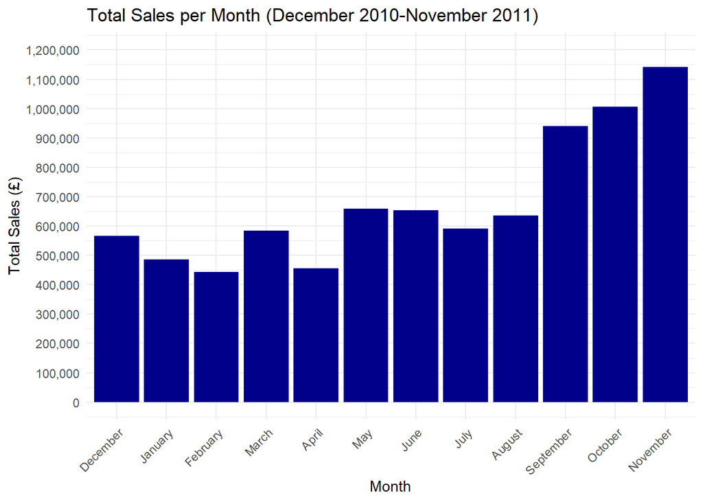

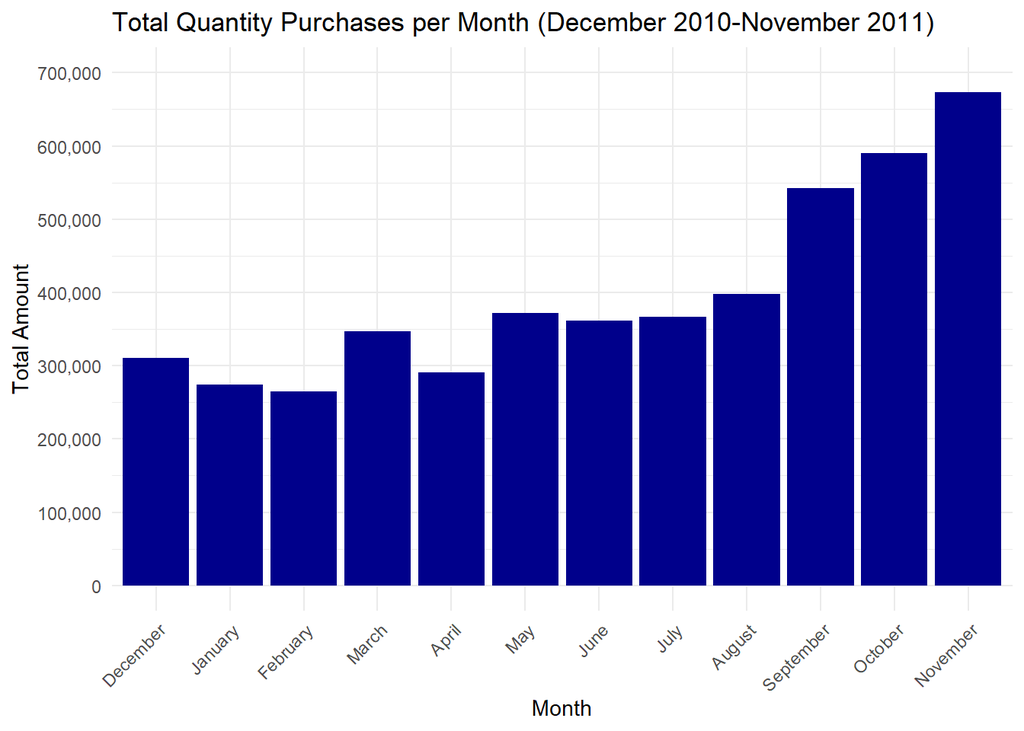

As we can see plainly above, the fall months of September, October, and November peak in terms of both quantity sold and sales.

To get a better idea of how sales are during the week and hour by month, we have created the following heat maps to see average sale per item, sales, and quantity sold across the days of the year by month.

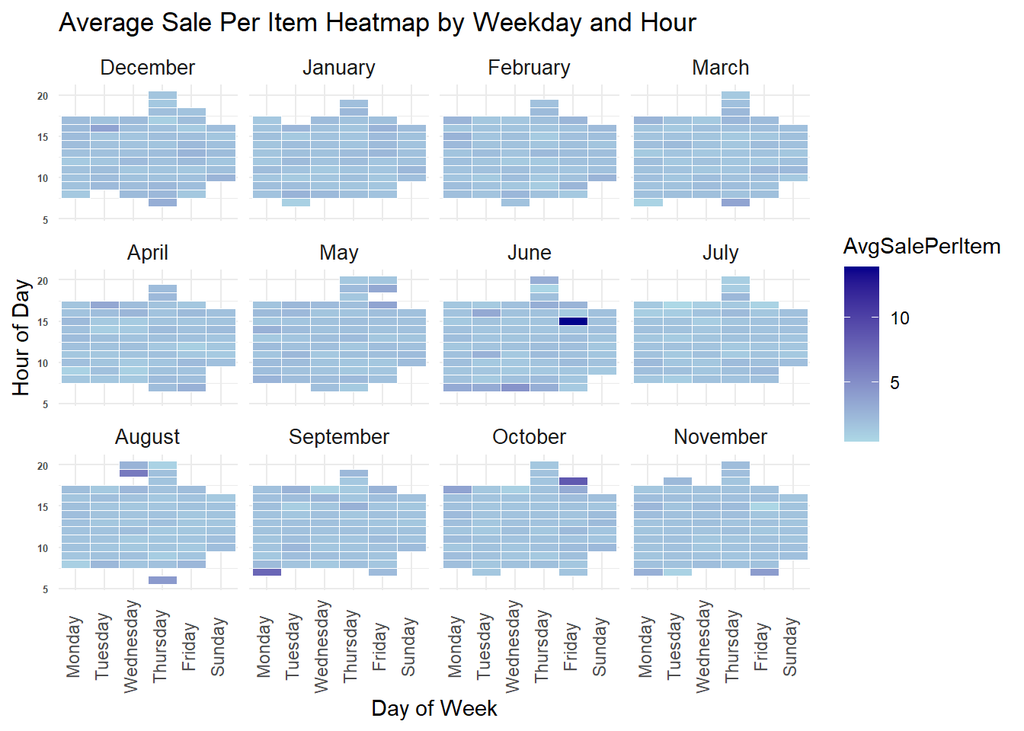

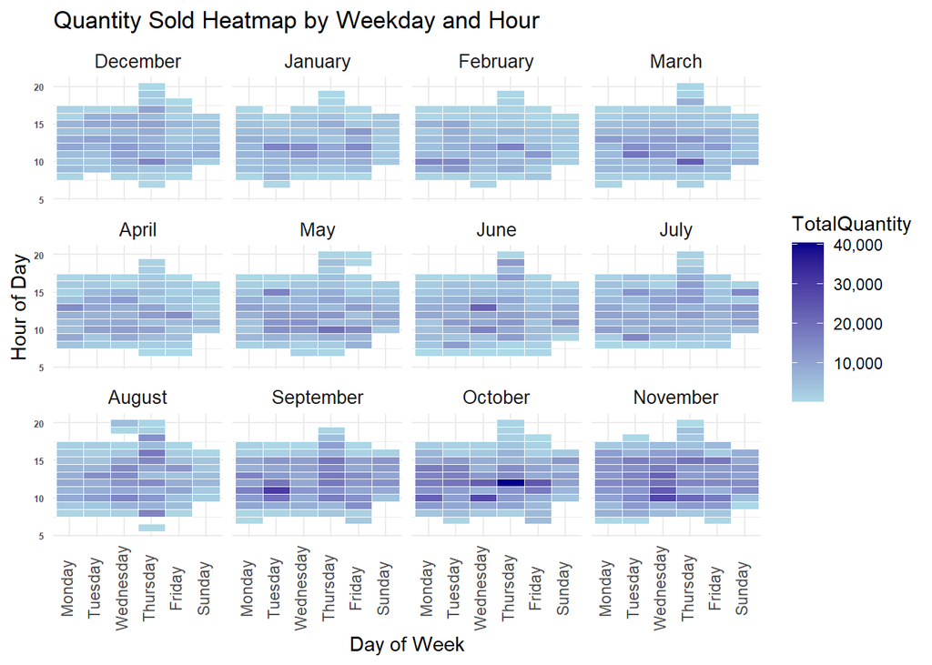

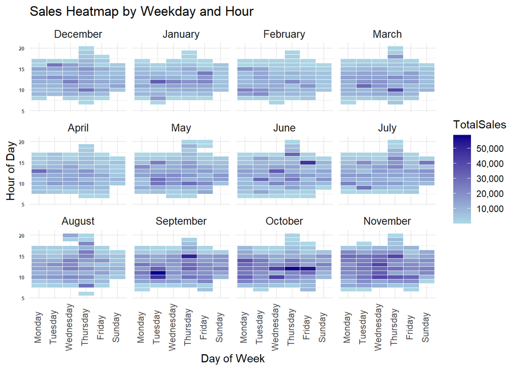

There are no sales on Saturday and Sunday sales are comparatively light throughout.

##### Total Items Per Order over Time

One of the most useful ways to find out when inventory is being overwhelmed by the number of purchases is seeing when bulk orders are being made. Below, we will see what time of year bulk orders are being made as well as what times of the week they are being made.

To begin with, let’s just see what the average sized order is throughout the year by month.

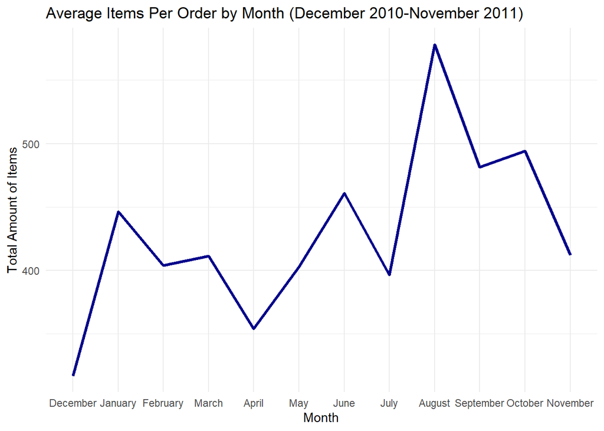

```r
average_sized_orders_month <- dbGetQuery(con, '
                 SELECT
                    InvoiceMonth,
                    AVG(TotalItemsPerOrder) AS AverageItemPerOrder
                 FROM cleaned_online_retail_data_final
                 WHERE NOT (InvoiceYear = "2011" AND InvoiceMonth = "December" AND InvoiceDay >= 1)
                 GROUP BY InvoiceMonth
                 ORDER BY AverageItemPerOrder DESC;')


average_sized_orders_month$InvoiceMonth <- factor(
  average_sized_orders_month$InvoiceMonth,
  levels = c("December", "January", "February", "March", "April", "May", "June", "July", "August", "September", "October",    "November")
)

ggplot(data=average_sized_orders_month, aes(x=InvoiceMonth, y=AverageItemPerOrder, group=1)) +
  geom_line(size = 1.2, color = "darkblue") +
  labs(
    title = "Average Items Per Order by Month (December 2010-November 2011)",
    x = "Month",
    y = "Total Amount of Items"
  ) +
  theme_minimal()
```

Overall, this time analysis allows us to see how sales shift from month to month and even from day to day (as we saw in the heat maps). Below, we will be adding more to this analysis by looking at analysis by country.

#### Analysis By Country

Now that a solid time sense has been established, it is critical that we look at sales across countries.

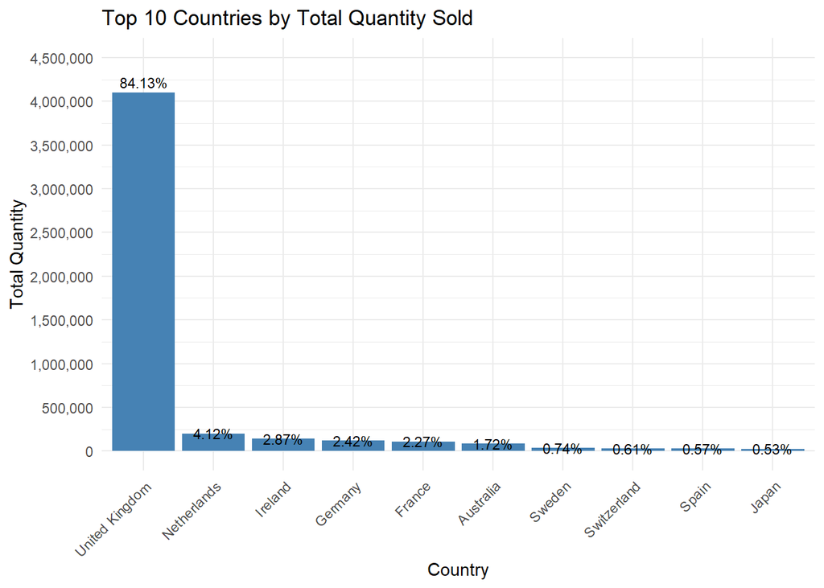

It can be clearly seen that the United Kingdom dominates in sales which comprises 84.13% of all the quantity sold for the company. Following them up are Netherlands, Ireland, Germany, France, and Australia, at 4.12%, 2.87%, 2.42%, 2.27%, and 1.72% respectively.

This indicates that the company has a very regionally concentrated market in the United Kingdom.

For further analysis of countries, the Tableau country sales dashboard allows users to see the quantities by month for each country, how much is being refunded in each country versus how much is being sold, and what the sales in each country are by month. This is all displayed on a map that is very easy to use. To navigate to it, go to the home directory of this project and go to “Visualizations” and then “Tableau Dashboards”. There is a file in there that can be opened in Tableau and inspected thoroughly.

#### Inspection of Products

One of the most important components of this analysis is looking at sales of products. Below, we will get the list of the top 15 products ordered by the amount they sold.

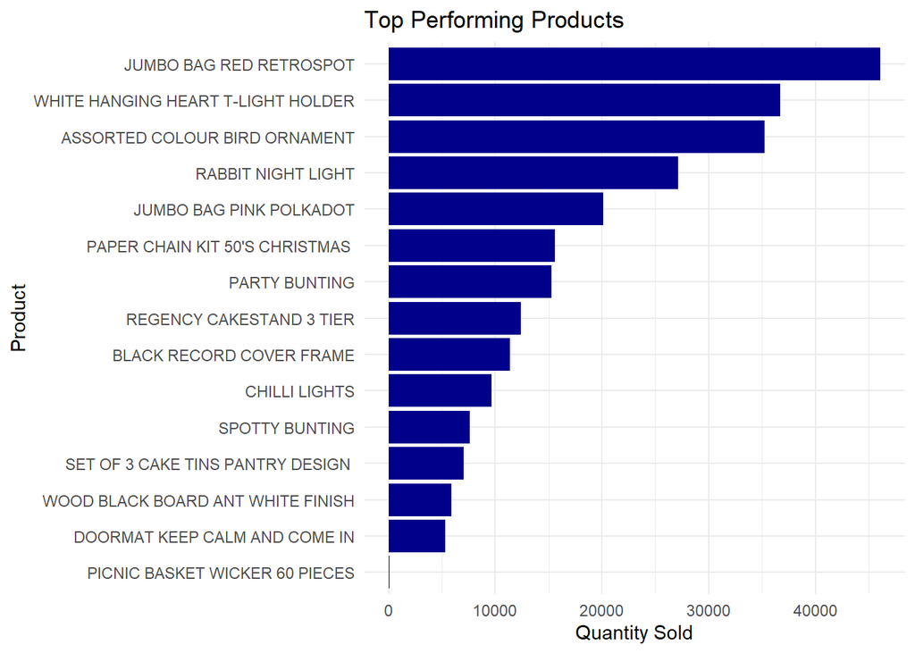

Below, we will utilize the PriceTier column we created earlier to see what common characteristics there are for these top products.

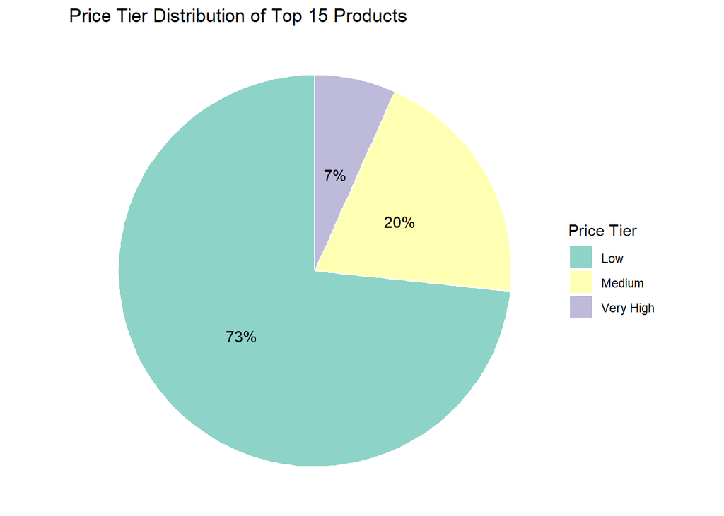

As can be seen, there is a very high concentration of of “low” price tiered products in this top 15, with them comprising 73% of that amount. 20% is “medium” and 7% is “very high”.

*Note refer to the preparation section for a refresher on the tiers*

Below, we will combine that PriceTier column information with the QuantityTier to see what percentage these top orders comprise.

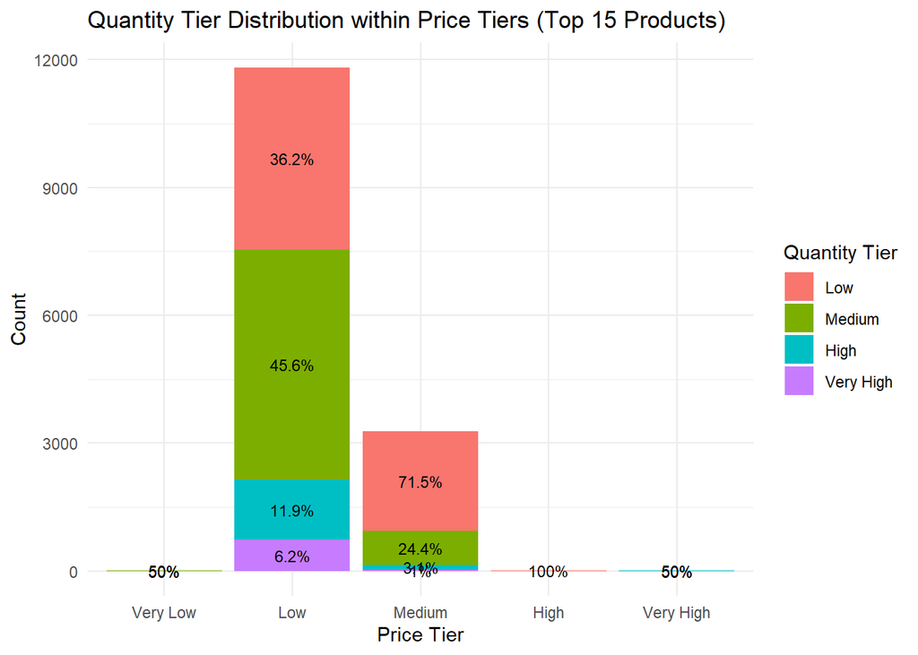

We can see that for “low” PriceTier products, 63.8% of those products have a “medium” quantity tier or higher. This is significant as this indicates that these low-priced products will need to be extra stocked not just because of their high sales but because of their tendency to be bought in higher quantities.

Below, we are going to do the same for low-performing products to see what indicates their status among the different tiers and repeat customer column.

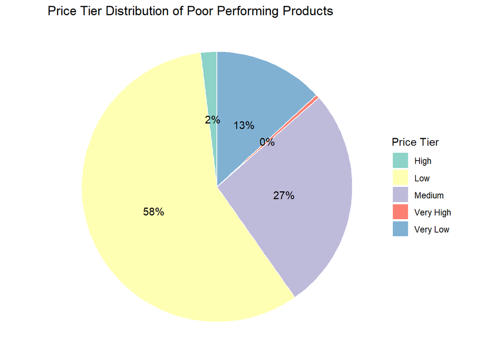

Compared to the top performing products before, there seems to be an increase of diversity in the PriceTier of these products. 13% of these poor performing products are identified as very low, 58% as low, 27% as medium, 2% as high and a very small percentage as very high.

This points to “Low” PriceTier products making up a vast amount of the number of products, but also that lower performing products tend to be of slightly higher values than the top performing products.

#### Low-performing Products and Repeat Customer Analysis

```
## The amount of low performing products with no repeat customers buying them: 33
```

```
## The amount of top 922 performing products with no repeat customers buying them: 0
```

We can see that among the poor performing products, there are a number of products that have not been purchased by repeat customers. In the top 922 products, every single product has been bought by a repeat customer.

This implies a heavy correlation between repeat customers and the success of products.

With these products analyzed thoroughly, we can now look at refunded orders and detect some potential fraud issues as well as to determine what products are not worth stocking, and what times refunds are taking place.

#### Refunded Orders Analysis

To begin with, the exact percentage of refunded orders is displayed below:

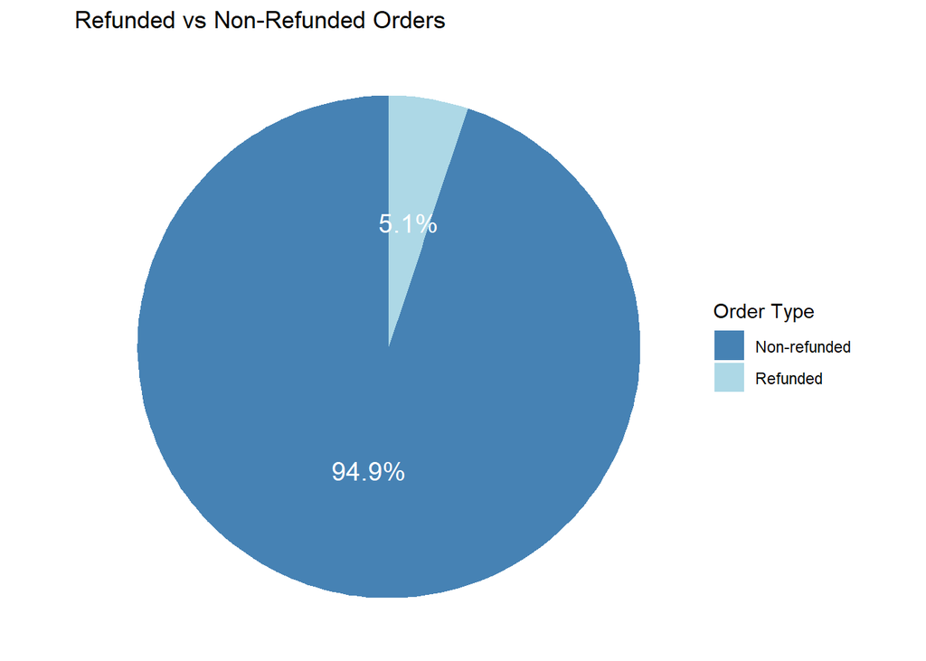

As we can see, the amount of refunded orders in terms of quantity comprise of 5.1% of the total amount of orders in the data set representing a small, but meaningful part of the story we can tell with this data.

Something useful to see between refunded and non-refunded purchases is whether the amounts in those purchases differ at all. Below, we will use some code to see if there is a difference.

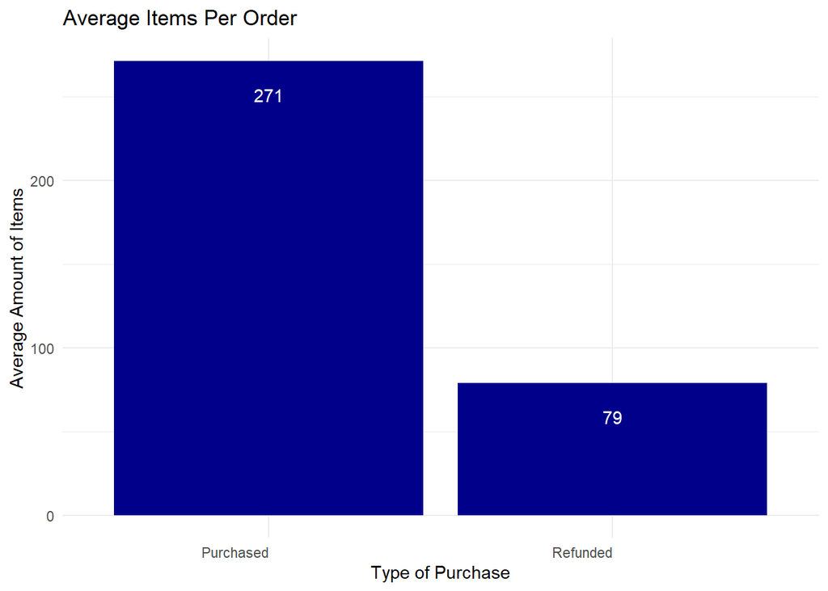

##### Refunds By Country

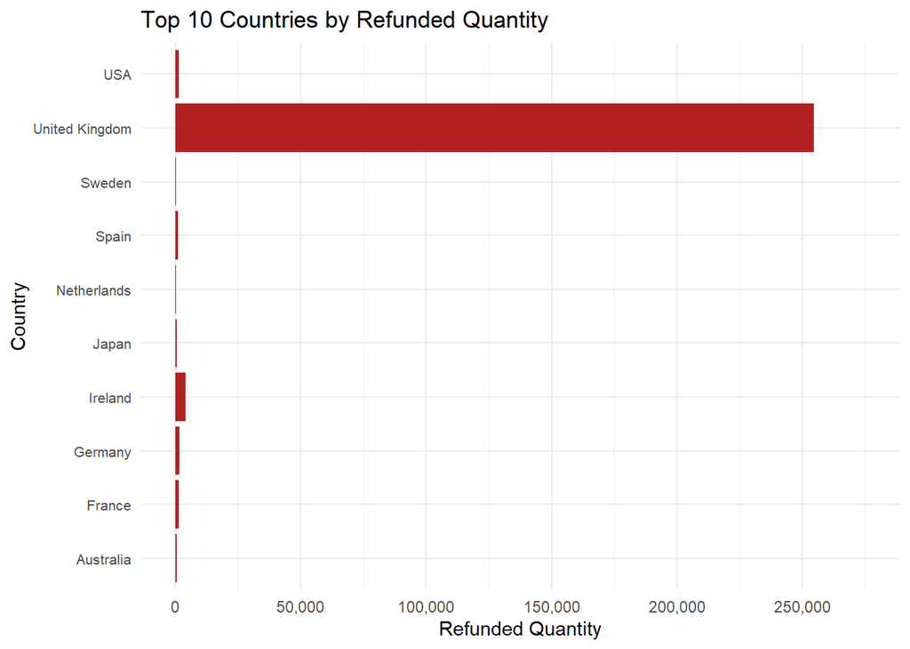

#### Refunds Across Time

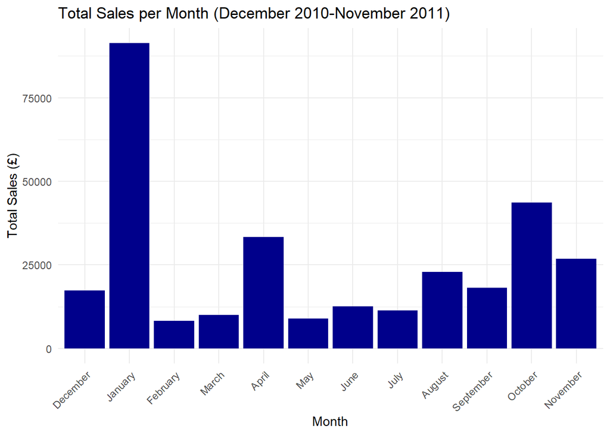

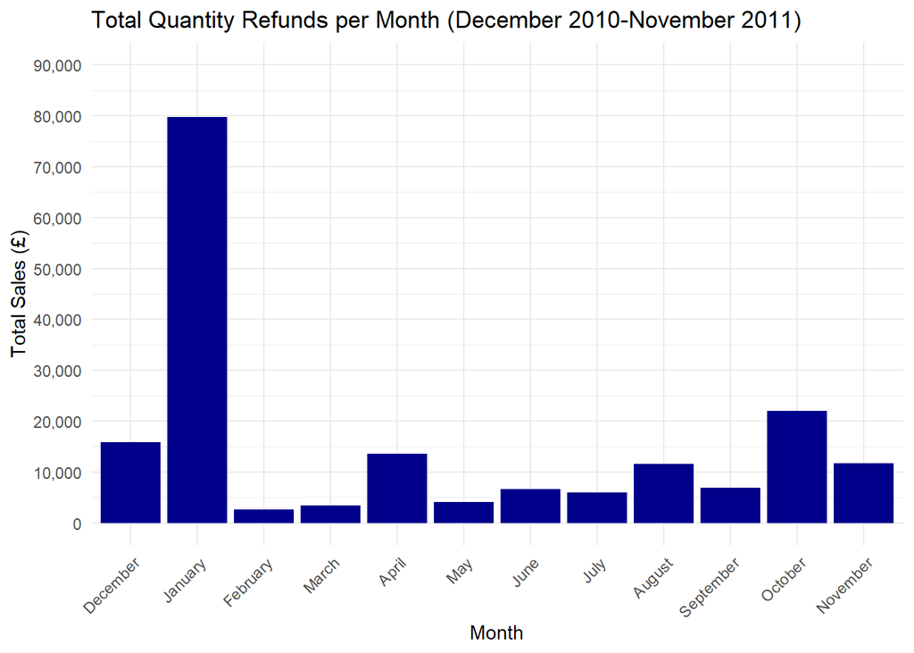

As we can see above, refunded purchases seem to come after the Christmas shopping season has concluded, with there being a lot of refunds being recorded in the month of January. Later on in the year there are some returns in the fall, which is when sales start to increase (see above monthly sales analysis).

Overall, this indicates refunds are only concentrated within given parts of the year and are not something that is a systemic wide-reaching problem in the organization.

##### Refunds By Product

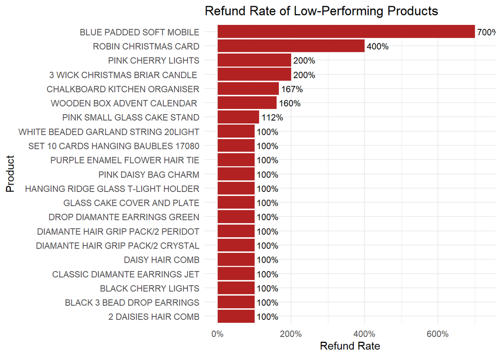

This indicates that these products should be immediately discontinued and no longer stocked. It also helps to indicate that products with higher refund rates tend to be lower performing products, allowing easy filtering for what is worth selling.

## Recommendations Based off of the Analysis

Throughout the analysis, we made a variety of different findings such as the high concentration of relatively lower-priced goods making up a vast amount of purchases, the high refund rates of certain products, and how sales differ by time and country.

Now that we are in the act section we can properly use these findings to make clear and useful actions that will help the company decide on what to pursue in terms of long term action.

#### Product Conclusions

Thus, it seems that inventory should prioritize these low-priced products as doing so could increase revenue by ensuring sufficient stock during peak demand periods.

#### Addressing High Refund Products

Additionally, other managers within the company should be informed of these particularly high rates as the problem could lay outside of inventory’s purview.

#### Refund Preparation after Christmas Holiday Season

Refunds constitute ~5% of all items sold, with most occurring in January following the holiday season. Inventory planning should account for this predictable post-holiday return surge by streamlining return logistics and anticipating stock write-backs.

This ensures that returned items can be processed quickly and efficiently, minimizing their financial impact.

#### Work on Improving Customer Retention

Top-performing products are closely linked to repeat customers, while many poor performers lack repeat purchases altogether. To leverage this, inventory efforts should emphasize products that are favored by repeat buyers.

Complementary marketing strategies such as loyalty programs, targeted promotions, or product bundling could further strengthen customer retention and reinforce inventory efficiency.

## Conclusion

This analysis provides a roadmap for optimizing inventory, reducing refund-related losses, and boosting customer retention. By prioritizing low-priced, high-demand products and tailoring stocking to seasonal and regional trends, the company can enhance operational efficiency and profitability.